# SeabornPlots

```python
#Toggle code view
from IPython.display import HTML
HTML('''<script>
code_show=true;
function code_toggle(){
if (code_show){
$('div.input').hide();
document.getElementById('btn_toggle').value="Show Code";
}else {
$('div.input').show();
document.getElementById('btn_toggle').value="Hide Code";
}
code_show=!code_show
}
$(document).ready(code_toggle);
</script>
<style>
.output_png {
    display: table-cell;
    text-align: center;
    vertical-align: middle;
</style>
<form action="javascript:code_toggle()">
<input style="float:right" type="submit" id="btn_toggle">

''')
```

```python
import seaborn as sns
import matplotlib.pyplot as plt
import numpy as np
import pandas as pd
%matplotlib inline
from matplotlib.ticker import PercentFormatter
import random
```

```python
#Visualization settings
sns.set_style(style='white')
sns.set(rc={
    'figure.figsize': (12,7),
    'axes.facecolor': 'white',
    'axes.grid': True,
    'grid.color': '.9',
    'axes.linewidth' : 1.0,
    'grid.linestyle': u'-'},
    font_scale=1.5)
custom_colors = ["#3498db", "#95a5a6","#34495e", "#2ecc71", "#e74c3c"]
sns.set_palette(custom_colors)
```

## 1.relplot

```python
tips = sns.load_dataset('tips')
tips.head()
```

|  | total_bill | tip | sex | smoker | day | time | size |
| --- | --- | --- | --- | --- | --- | --- | --- |
| 0 | 16.99 | 1.01 | Female | No | Sun | Dinner | 2 |
| 1 | 10.34 | 1.66 | Male | No | Sun | Dinner | 3 |
| 2 | 21.01 | 3.50 | Male | No | Sun | Dinner | 3 |
| 3 | 23.68 | 3.31 | Male | No | Sun | Dinner | 2 |
| 4 | 24.59 | 3.61 | Female | No | Sun | Dinner | 4 |

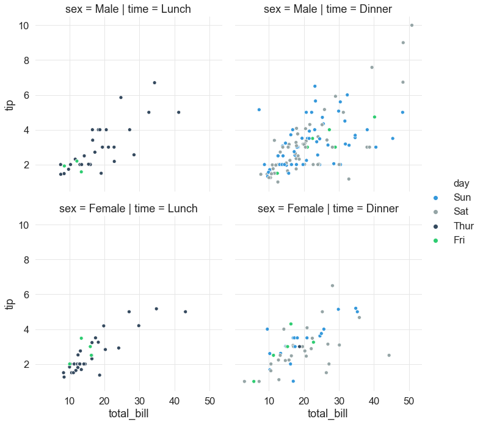

```python
sns.relplot(data=tips,x="total_bill",y="tip", hue="day", col="time", row="sex");
```

# 2.Scatterplot

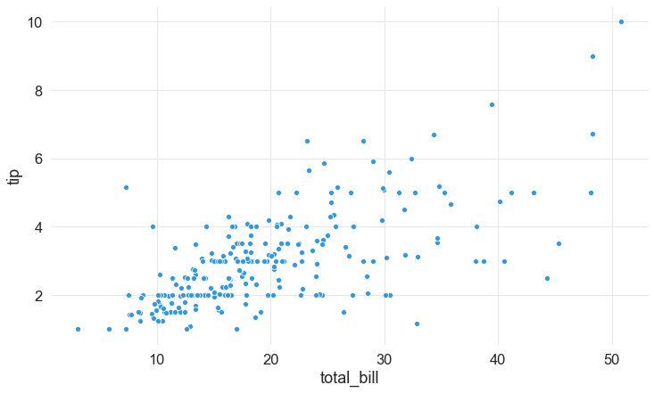

```python
sns.scatterplot(data=tips,x="total_bill", y="tip");
```

# 3.Lineplot

```python
flights = sns.load_dataset("flights")
flights
```

|  | year | month | passengers |
| --- | --- | --- | --- |
| 0 | 1949 | January | 112 |
| 1 | 1949 | February | 118 |
| 2 | 1949 | March | 132 |
| 3 | 1949 | April | 129 |
| 4 | 1949 | May | 121 |
| ... | ... | ... | ... |
| 139 | 1960 | August | 606 |
| 140 | 1960 | September | 508 |
| 141 | 1960 | October | 461 |
| 142 | 1960 | November | 390 |
| 143 | 1960 | December | 432 |

144 rows × 3 columns

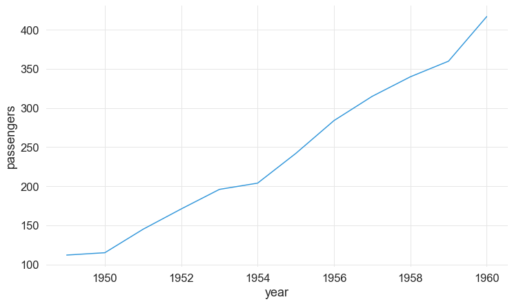

```python
Jan_flights = flights.query("month == 'January'" )
sns.lineplot(data=Jan_flights, x="year", y="passengers");
```

```
Passing the entire dataset in long-form mode will aggregate over repeated values (each year) to show the mean and 95% confidence interval:
```

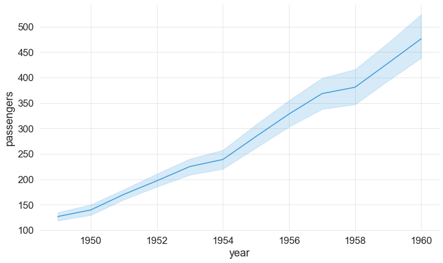

```python
sns.lineplot(data=flights, x="year", y="passengers");
print ("Passing the entire dataset in long-form mode will aggregate over repeated values (each year) to show the mean and 95% confidence interval:")
```

```
Assign a grouping semantic (hue, size, or style) to plot separate lines
```

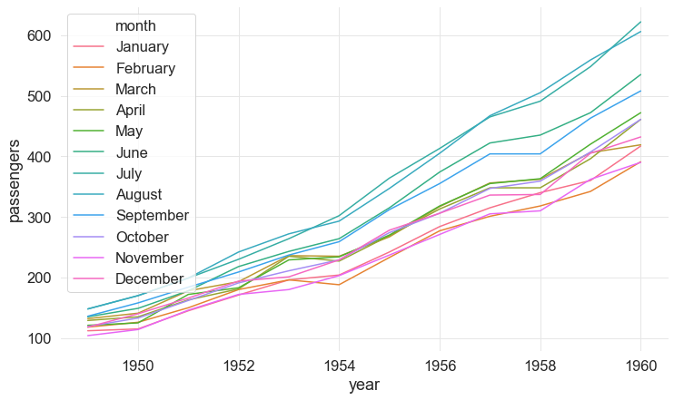

```python
sns.lineplot(data=flights,x="year", y="passengers", hue="month");
print ("Assign a grouping semantic (hue, size, or style) to plot separate lines")
```

# 4.Catplot

Shows the relationship between a numerical variable and one more categorical variables.

```python
exercise = sns.load_dataset("exercise")
```

```python
exercise
```

|  | Unnamed: 0 | id | diet | pulse | time | kind |
| --- | --- | --- | --- | --- | --- | --- |
| 0 | 0 | 1 | low fat | 85 | 1 min | rest |
| 1 | 1 | 1 | low fat | 85 | 15 min | rest |
| 2 | 2 | 1 | low fat | 88 | 30 min | rest |
| 3 | 3 | 2 | low fat | 90 | 1 min | rest |
| 4 | 4 | 2 | low fat | 92 | 15 min | rest |
| ... | ... | ... | ... | ... | ... | ... |
| 85 | 85 | 29 | no fat | 135 | 15 min | running |
| 86 | 86 | 29 | no fat | 130 | 30 min | running |
| 87 | 87 | 30 | no fat | 99 | 1 min | running |
| 88 | 88 | 30 | no fat | 111 | 15 min | running |
| 89 | 89 | 30 | no fat | 150 | 30 min | running |

90 rows × 6 columns

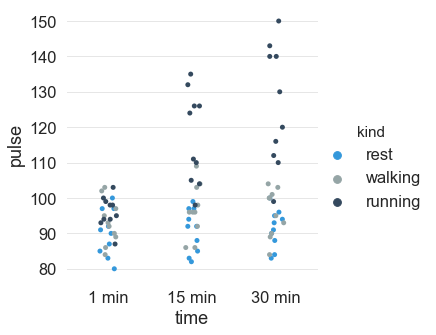

```python
sns.catplot(data=exercise, x="time", y="pulse", hue="kind");
```

# 5.Stripplot

Draw a scatterplot where one variable is categorical.

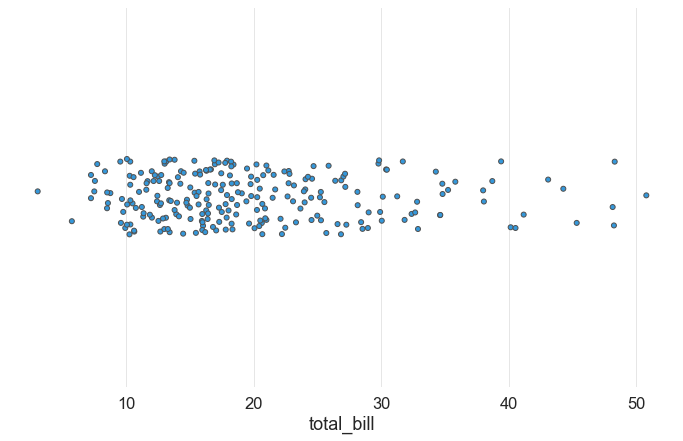

```python
sns.stripplot(data=tips,x="total_bill",linewidth=1);
```

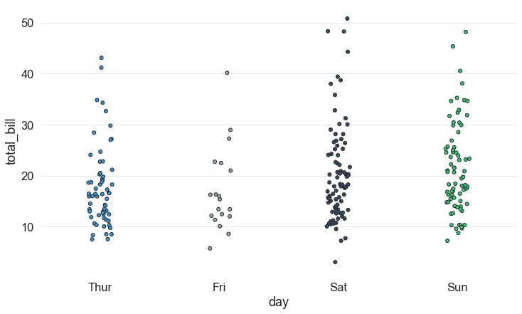

```python
sns.stripplot(data=tips, x="day",y="total_bill",linewidth=1);
```

# 6.Swarmplot

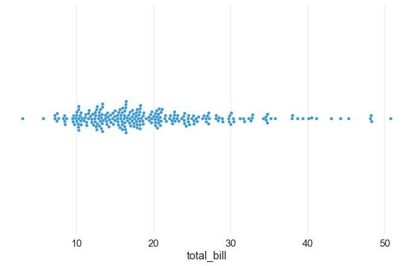

```python
sns.swarmplot(x="total_bill", data=tips);
```

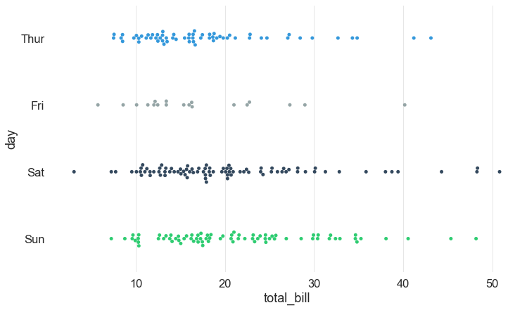

```python
sns.swarmplot(data=tips,x="total_bill",y="day");
```

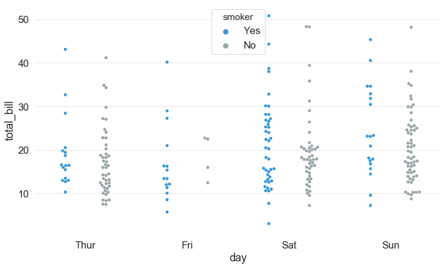

```python
sns.swarmplot(data=tips,x="day",y="total_bill",hue="smoker",dodge=True);
```

# 7. Boxplot

Draw a box plot to show distributions with respect to categories.

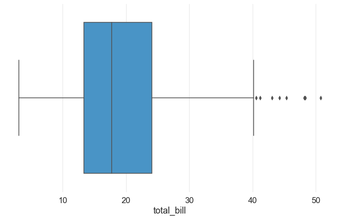

```python
sns.boxplot(data=tips,x="total_bill");
```

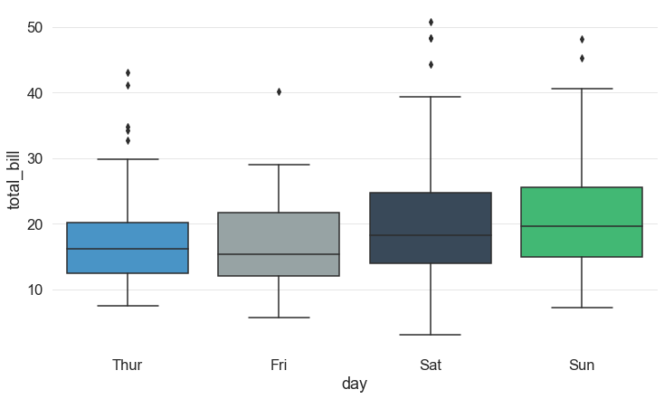

```python
sns.boxplot(data=tips,y="total_bill",x="day");
```

# 8. Violing plot

Draw a combination of boxplot and kernel density estimate.

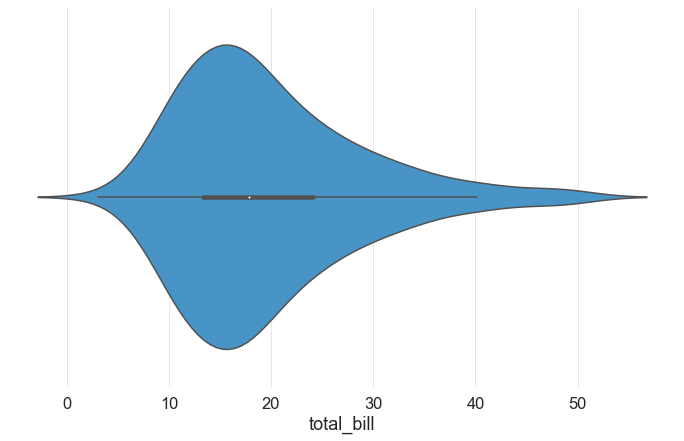

```python
    sns.violinplot(data=tips, x="total_bill");
```

# 9. Boxenplot

Draw an enhanced box plot for larger datasets.

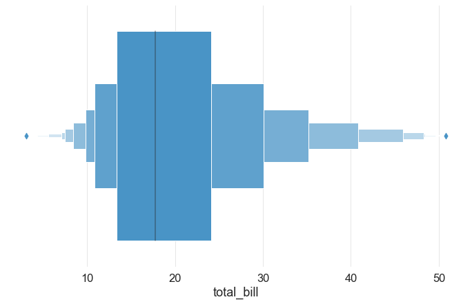

```python
sns.boxenplot(data=tips,x="total_bill");
```

# 10. Pointplot

Show point estimates and confidence intervals using scatter plot glyphs.

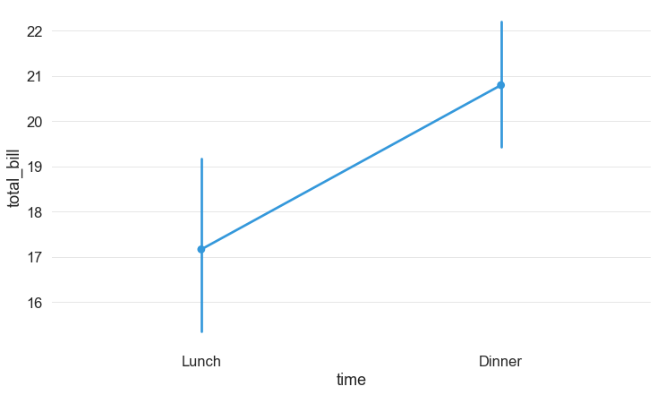

```python
sns.pointplot(data=tips,x="time",y="total_bill");
```

# 11. Barplot

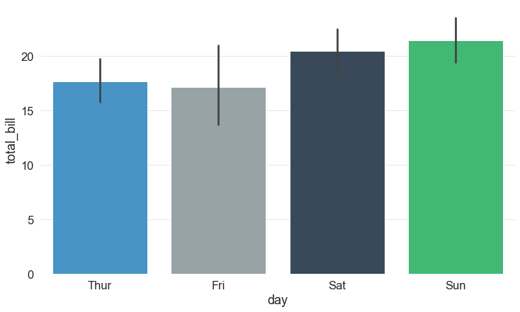

```python
sns.barplot(data=tips,x="day",y="total_bill");
```

# 12. Countplot

```python
titanic=sns.load_dataset("titanic")
```

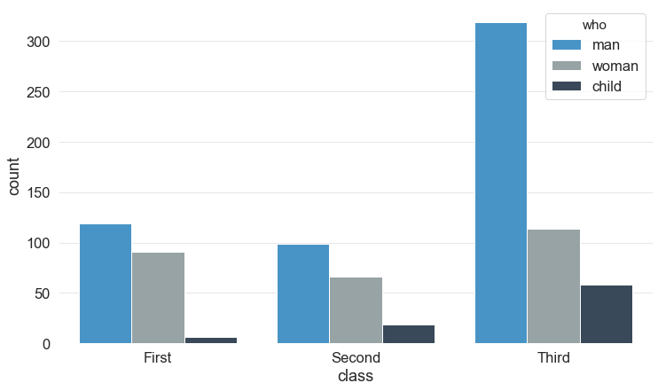

```python
sns.countplot(data=titanic,x="class",hue="who");
```

# 13. Distplot

This function combines the matplotlib hist function (with automatic calculation of a good default bin size) with the seaborn kdeplot() and rugplot() functions. It can also fit scipy.stats distributions and plot the estimated PDF over the data.

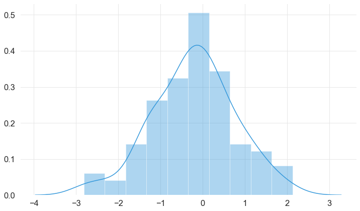

```python
x=np.random.randn(100)
sns.distplot(x);
```

# 14. Kdeplot

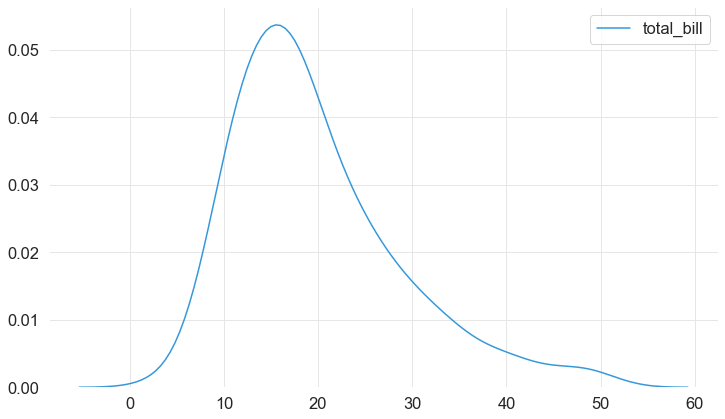

```python
sns.kdeplot(data=tips.total_bill);
```

# 15. Rugplot

Plot marginal distributions by drawing ticks along the x and y axes.

This function is intended to complement other plots by showing the location of individual observations in an unobstrusive way.

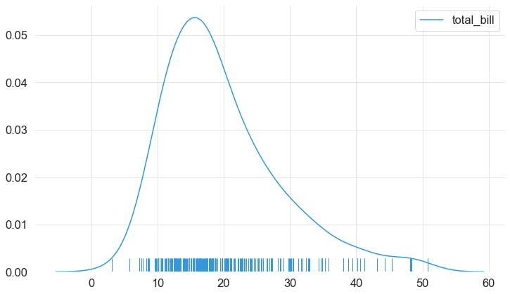

```python
sns.kdeplot(data=tips.total_bill);
sns.rugplot(a=tips.total_bill);
```

# 16. lmplot

Plot data and regression model fits across a FacetGrid.

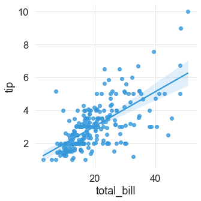

```python
sns.lmplot(data=tips,x="total_bill", y="tip");
```

# 17.regplot

Plot data and a linear regression model fit.

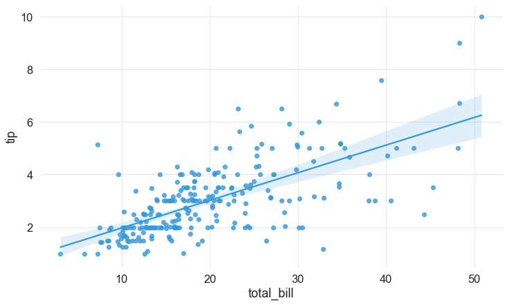

```python
sns.regplot(data=tips,x= 'total_bill', y='tip');
```

# 18. Heatmap

```
[[ 0.52011682 -0.34694243  0.91812824 -0.61555062]
 [-0.63438531 -0.79990563  0.43214891 -0.63853397]
 [ 1.0475609  -1.49896741 -0.83388662  0.37877433]]
```

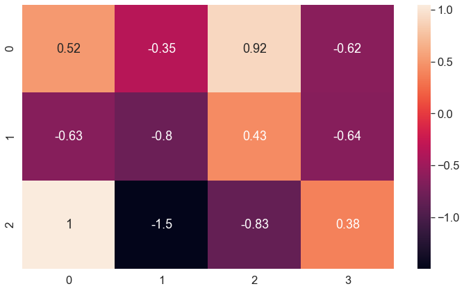

```python
uniform_data=np.random.randn(3,4)
print (uniform_data)
sns.heatmap(uniform_data,annot=True);
```

# 19. Clustermap

Plot a matrix dataset as a hierarchically-clustered heatmap.

```python
iris= sns.load_dataset("iris")
iris.pop("species")
iris =iris.loc[0:3,]
iris
```

|  | sepal_length | sepal_width | petal_length | petal_width |
| --- | --- | --- | --- | --- |
| 0 | 5.1 | 3.5 | 1.4 | 0.2 |
| 1 | 4.9 | 3.0 | 1.4 | 0.2 |
| 2 | 4.7 | 3.2 | 1.3 | 0.2 |
| 3 | 4.6 | 3.1 | 1.5 | 0.2 |

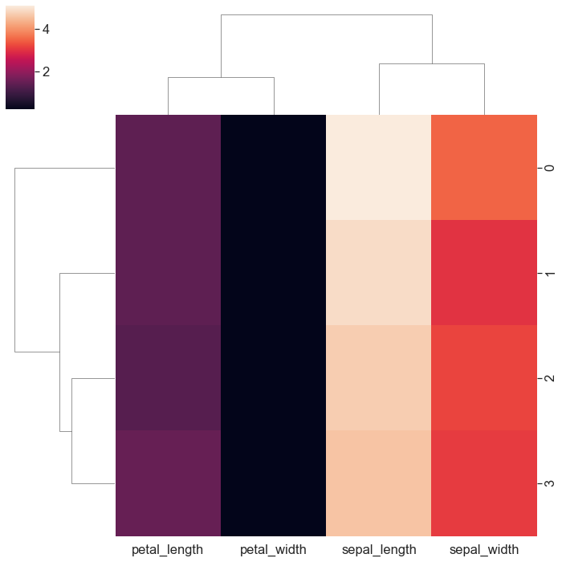

```python
sns.clustermap(data=iris);
```

# 20. Facetgrid

```
Multiplot grid for plotting conditional relationships
```

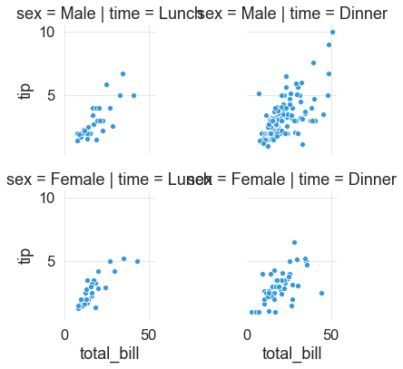

```python
g=sns.FacetGrid(tips, col="time", row="sex");
g.map(sns.scatterplot,"total_bill","tip");
```

# 21. Parplot

plot pairwise relationship of variables within dataset.

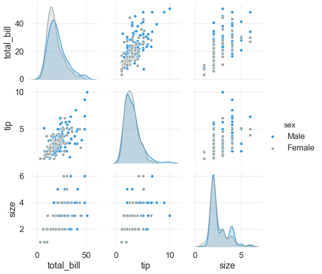

```python
sns.pairplot(data=tips, hue="sex");
```

# 22. PairGrid

Subplot grid for plotting pairwise relationships in a dataset.

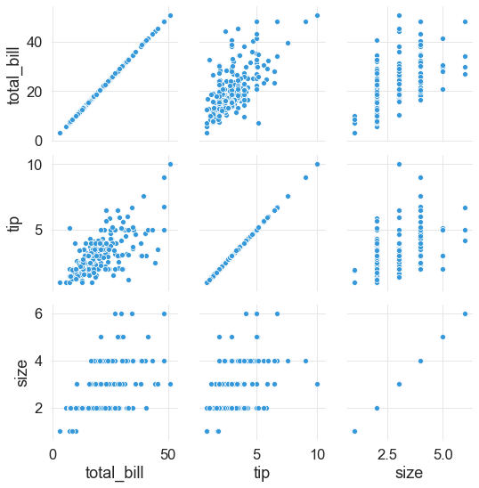

```python
graph=sns.PairGrid(tips);
graph.map(sns.scatterplot);
```

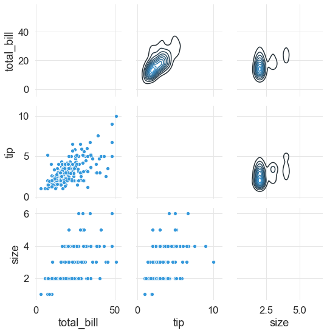

```python
graph=sns.PairGrid(data=tips);
graph.map_lower(sns.scatterplot);
graph.map_upper(sns.kdeplot);
```

# 23. jointplot

Draw a plot of two variables with bivariate and univariate graphs

```python
penguins = sns.load_dataset("penguins")
penguins.head()
```

|  | species | island | bill_length_mm | bill_depth_mm | flipper_length_mm | body_mass_g | sex |
| --- | --- | --- | --- | --- | --- | --- | --- |
| 0 | Adelie | Torgersen | 39.1 | 18.7 | 181.0 | 3750.0 | MALE |
| 1 | Adelie | Torgersen | 39.5 | 17.4 | 186.0 | 3800.0 | FEMALE |
| 2 | Adelie | Torgersen | 40.3 | 18.0 | 195.0 | 3250.0 | FEMALE |
| 3 | Adelie | Torgersen | NaN | NaN | NaN | NaN | NaN |
| 4 | Adelie | Torgersen | 36.7 | 19.3 | 193.0 | 3450.0 | FEMALE |

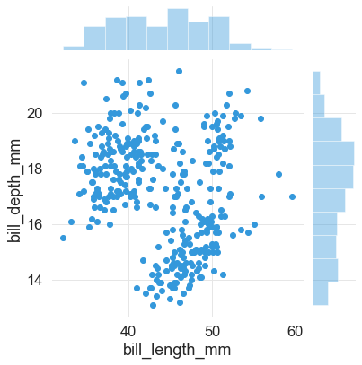

```python
sns.jointplot(data=penguins, x="bill_length_mm", y="bill_depth_mm");
```

# set_palette

Set the matplotlib color cycle using seaborn palette

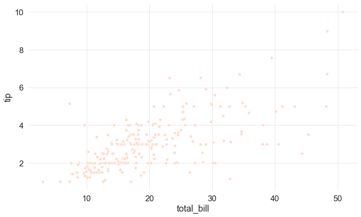

```python
sns.set_palette('Reds')
sns.scatterplot(data=tips, x="total_bill", y="tip");
```

# Multiple plots in same graph

```python
basket=[]
apple=("Apple," * random.randint(1,100)).split(",")
grapes=("Grape," * random.randint(1,100)).split(",")
orange=("Orange," * random.randint(1,100)).split(",")
basket.extend(apple)
basket.extend(grapes)
basket.extend(orange)
basket=pd.Series(data=basket,name="Item")
basket.drop(basket[basket.values==""].index,inplace=True)
basket_value_cnt=basket.value_counts()
cum_percent=basket_value_cnt.cumsum()/basket_value_cnt.sum()*100
```

```python
sns.reset_defaults()
```

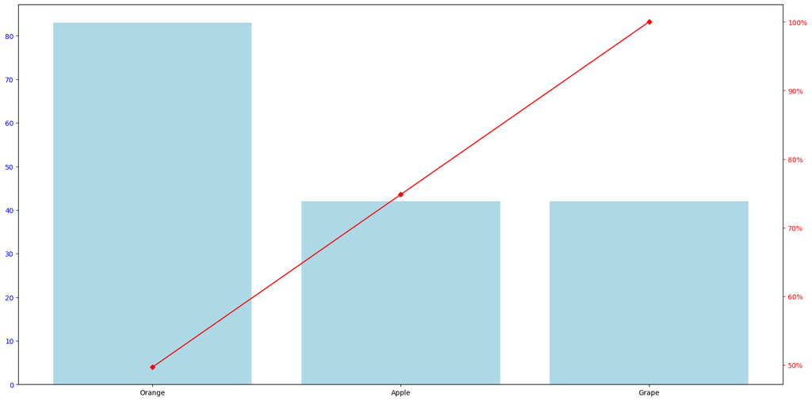

```python
fig,ax=plt.subplots(figsize=(20,10))
ax.bar(basket_value_cnt.index,basket_value_cnt.values,color='lightblue');

ax2=ax.twinx()
ax2.plot(cum_percent.index,cum_percent,color='red',marker='D',ms=5)
ax2.yaxis.set_major_formatter(PercentFormatter())

ax.tick_params(axis='y', colors='blue')
ax2.tick_params(axis='y',colors='red')
plt.show()
```